# ViSiElSe Step by Step

2016-07-05

## Few words about ViSiElse

VisiElse is **a graphical tool** designed to visualize and to **give an overview of behavioural observations** realized on individuals or groups. For example, ViSiElse allows **visualization of raw data** during experimental observations of the **realization of a procedure** like a medical algorithm. It graphically presents an overview of individuals and group **actions usually acquired from timestamps during video recorded sessions**. Options of the package allow adding graphical information as statistical indicators (mean, standard deviation, quantiles or statistical tests) but also for each action green or black zones providing visual information about the accuracy of the realized actions.

# A step by step example

We are presenting how to create a completely artificial example in order to provide a simple and clear overview of this package.

## The process : Making coffee

The process underlining making coffee corresponds to a **5 steps procedure**.

- 1- Taking the coffee
- 2- Fill the machine with coffee
- 3- Fill the tank with water
- 4- Push the Button
- 5- Drink the coffee

All those actions are punctual.

## The Dataset

Concerning the procedure, **execution times** for punctual actions are needed. The data.frame must also have a column to **identify individuals**.

```r
coffee <- c(  58, 11,  5, 53, 53, 59, 24, 59, 46, 20)
fill_coffee <- c(162,  57,103,154,165,132,  74, 107, 104,  93)
fill_water <- c(  66,  92,54, 78, 74, 114, 91, 129, 71, 56)
push_B <- c( 74, 99, 62, 84, 83, 120, 95, 129, 80, 63 )
drink <- c( 472, 176, 475, 283, 265, 207, 234, 184, 490, 520)
X <- data.frame(id = seq(1,10), coffee, fill_coffee,fill_water,push_B,drink)
head(X)
```

```
##   id coffee fill_coffee fill_water push_B drink
## 1  1     58         162         66     74   472
## 2  2     11          57         92     99   176
## 3  3      5         103         54     62   475
## 4  4     53         154         78     84   283
## 5  5     53         165         74     83   265
## 6  6     59         132        114    120   207
```

## First plot

Executions of punctual actions are distributed on the axis of time divided in intervals. The ammount of individuals having done the action in an interval is represented by intensity of color.

By default :

- Actions are ordered after their order in the data.frame X
- Pixel of time is set to 20
- The time units ae seconds
- Median and quartiles are drawn

```r
visi1 <- visielse(X)
```

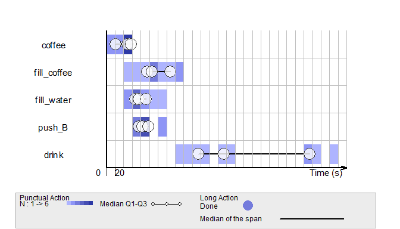

### The pixel of time

For punctual actions data are aggregated in a matrix $M$ . The number of row of $M$ is the number of action and its number of columns is $[ ( max(X)-t_{0} )/pixel]$ .

$M_{i,j}$ contains the number of observations of the $i$ -th punctual action (by the order of the ViSibook object) between $t_0 + (j-1)*pixel$ included and $t_0 + j*pixel$ excluded.

#### Changing the pixel of time

```r
visi1 <- visielse(X, pixel = 10)
```

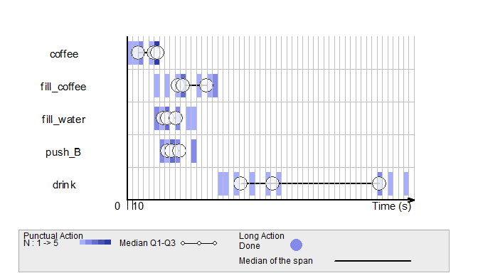

### Indicators

ViSiElse propopse by default to plot as white cirele median and quartiles.

#### Plot Mean and standard deviation

```r
visi1 <- visielse(X,informer = "mean")
```

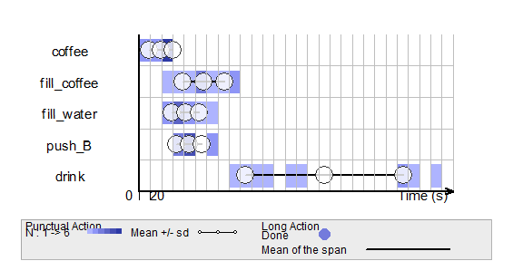

#### Do not plot indicators

```r
visi1 <- visielse(X,informer = NULL)
```

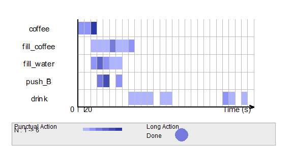

## The ViSibook

The ViSibook is containing the structure of the behavioural process. If it is not given the function visielse computes it assuming the process is the ordered list of punctual actions given by the dataset colnames. It is possible either to extract the ViSiElse from a first execution of the visielse function or to build a data.frame respecting the condition for a ViSiBook.

### Extraction of the visibook from the data

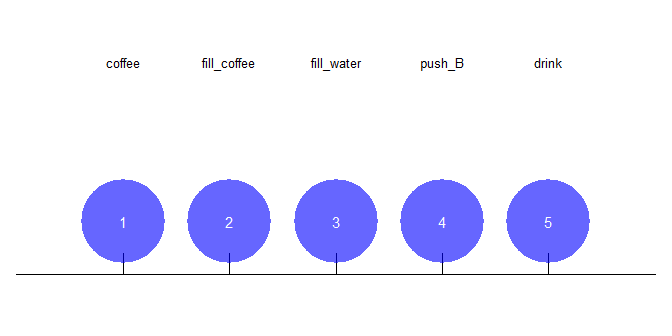

```r
visi1 <- visielse(X,informer = NULL, doplot = FALSE)
book <- visi1@book
plot(book)
```

### Structure of the book

The **minimum structure for a ViSibook** object must give for **each action** its **name** (without special characters but " _ " ), its **label**, its **type** (punctual or long).

```r
book
```

```
##      vars          label         typeA showorder deb fin
## [1,] "coffee"      "coffee"      "p"   "1"       NA  NA
## [2,] "fill_coffee" "fill_coffee" "p"   "2"       NA  NA
## [3,] "fill_water"  "fill_water"  "p"   "3"       NA  NA
## [4,] "push_B"      "push_B"      "p"   "4"       NA  NA
## [5,] "drink"       "drink"       "p"   "5"       NA  NA
```

#### Changing labels

By default the label are the same as the names of variable the the dataset, but plot.ViSigrid and plot.ViSibook use the label.

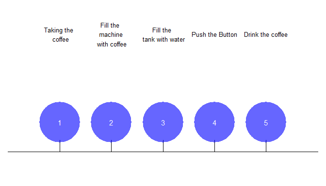

```r
book[,2]<- c("Taking the coffee",
"Fill the machine with coffee",
"Fill the tank with water",
"Push the Button",
"Drink the coffee")
plot(book)
```

```r
visi1 <- visielse(X, book=book, is.ViSibook = TRUE,informer = NULL)
```

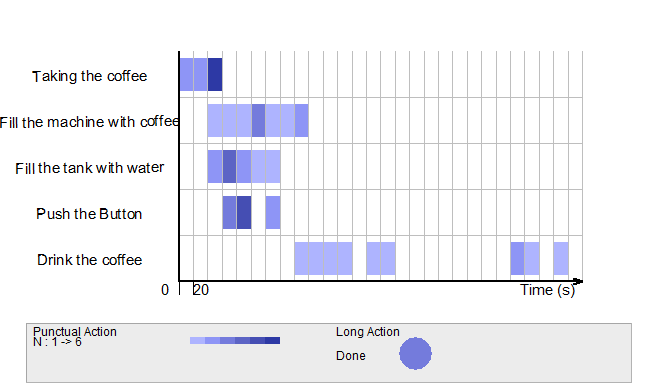

### Order of Actions in the process

The **order** is given by “showorder”. It is the order by which actions are supposed to happen.

#### Change the order

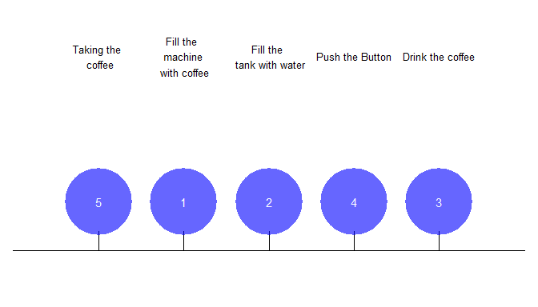

```r
book[,4]<- c(5,1,2,4,3)
plot(book)
```

```r
visi1 <- visielse(X, book=book, is.ViSibook = TRUE)
```

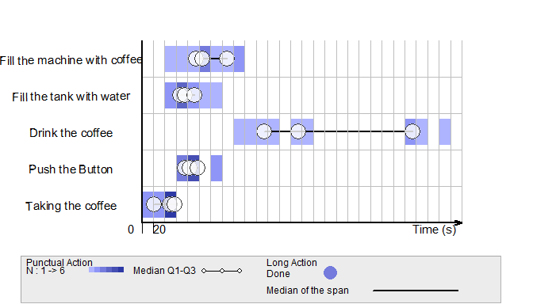

#### Ignored an action in the plot

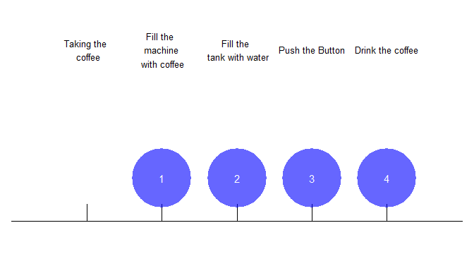

```r
book[,4]<- c(NA,1,2,3,4)
plot(book)
```

```r
visi1 <- visielse(X, book=book, is.ViSibook = TRUE)
```

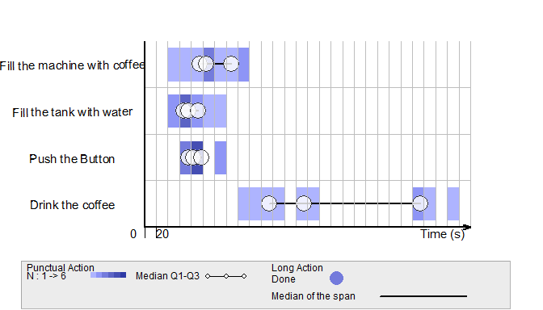

## Long Actions

Delays or long actions can be helpful to understand a prossess. ViSiElse considers two different types of actions: **punctual and long**. The actions called punctual are brief actions defined as a **time points**. The actions called long (or delays) are the ones defined by **duration**. They are characterized by both **a beginning punctual action and an ending one**. To defined a long action there is no need to change the dataset but only to add a line in the visibook. The slot typeA in the visibook psecify if the action is punctual (“p”) or long (“l”).

#### Adding a long Actions

```r
visi1 <- visielse( X )
```

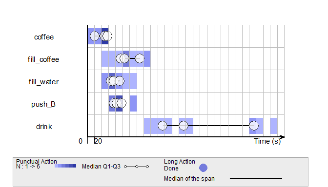

```r
book <- ConvertFromViSibook( visi1@book ) # Convert book into data.frame
add_delay <- c( "delay_coffee_push","Preparation","l","6","coffee","push_B")
book[6,] <- add_delay
book
```

```
##                vars       label typeA showorder    deb    fin
## 1            coffee      coffee     p         1   <NA>   <NA>
## 2       fill_coffee fill_coffee     p         2   <NA>   <NA>
## 3        fill_water  fill_water     p         3   <NA>   <NA>
## 4            push_B      push_B     p         4   <NA>   <NA>
## 5             drink       drink     p         5   <NA>   <NA>
## 6 delay_coffee_push Preparation     l         6 coffee push_B
```

### ViSiElse representation of long actions

ViSiElse represents each individual execution of a long action as an horizontal line when it is done.

```r
visi2 <- visielse( X=X , book=book,informer=NULL)
```

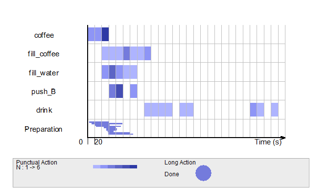

## Green & Black zones

### Punctuals actions

Green and black zone are introduced to help visualize time boundaries. To define green and black zone for punctual actions we will add the columns : * Green Zone : GZDeb and GZFin. * Black zone 1 : BZBeforeDeb and BZBeforeFin. * Black zone 2 : BZAfterDeb and BZAfterFin.

#### Fill coffee in the machine should be done between 1min and 2min

```r
book$GZDeb <- c(NA,60,NA,NA,NA,NA)
book$GZFin <- c(NA,120,NA,NA,NA,NA)
visi2 <- visielse( X=X , book=book,informer=NULL)
```

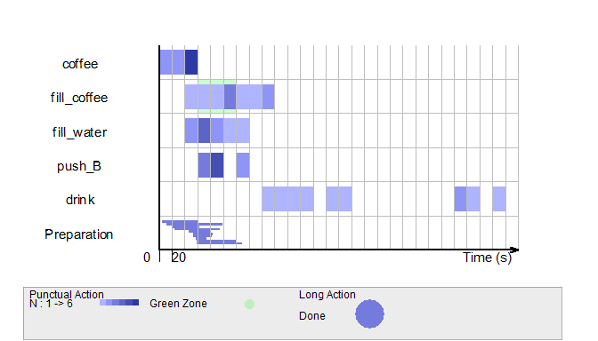

#### Fill coffee in the machine should not be done before 30s

```r
book$GZDeb <- c(NA,NA,NA,NA,NA,NA)
book$GZFin <- c(NA,NA,NA,NA,NA,NA)
book$BZBeforeDeb <- c(NA,0,NA,NA,NA,NA)
book$BZBeforeFin <- c(NA,30,NA,NA,NA,NA)
visi2 <- visielse( X=X , book=book,informer=NULL)
```

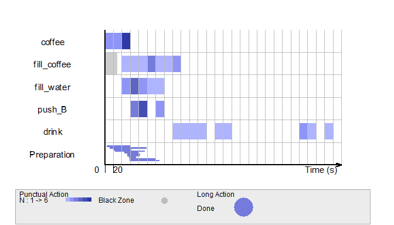

#### Fill coffee in the machine should be done between the second 1min and 2 min but not before 30s or after 3min

```r
book$GZDeb <- c(NA,60,NA,NA,NA,NA)
book$GZFin <- c(NA,120,NA,NA,NA,NA)
book$BZBeforeDeb <- c(NA,0,NA,NA,NA,NA)
book$BZBeforeFin <- c(NA,30,NA,NA,NA,NA)
book$BZAfterDeb <- c(NA,180,NA,NA,NA,NA)
book$BZAfterFin <- c(NA,Inf,NA,NA,NA,NA)
visi2 <- visielse( X=X , book=book,informer=NULL)
```

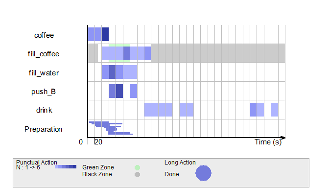

### Long Action

ViSielse allow reprensention of two types of black zone for long action : * A deadline not to cross : “span” * A duration not to exceed : “time”

#### The preparation should not last more than 2min 30s

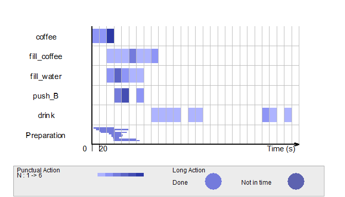

```r
visi1 <- visielse( X,  doplot = FALSE )
book <- ConvertFromViSibook( visi1@book ) # Convert book into data.frame
add_delay <- c( "delay_coffee_push","Preparation","l","6","coffee","push_B")
book[6,] <- add_delay
book$BZLong <- c(rep(NA,5),150)
book$BZLtype <- c(rep(NA,5),"time")
visi1 <- visielse( X, book=book , informer = NULL)
```

#### The preparation should be done at 2min 30s

```r
book$BZLong <- c(rep(NA,5),150)
book$BZLtype <- c(rep(NA,5),"span")
visi1 <- visielse( X, book=book ,informer = NULL)
```

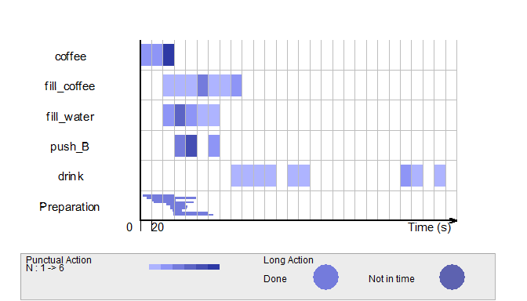

## Group

To define two groups you need to : * Add a vector containing the group for each individuals * Select a metohd of visualizing groups

### Method : Cut

Each groups is represented one under the other.

```r
group <- c( "group2","group1","group2","group1","group1","group2","group1","group1","group1","group2")
visi1 <- visielse( X,group=group, book=book ,informer = NULL, method = "cut")
```

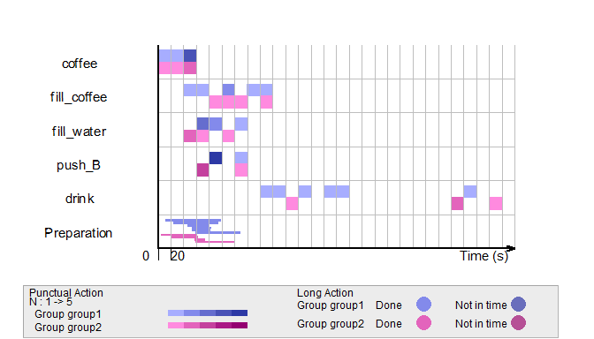

### Method : Join

Groups are spatially mixed but they are represented by different colors.

```r
group <- c( "group1","group1","group1","group1","group1","group2","group2","group2","group2","group2")
visi1 <- visielse( X,group=group, book=book ,informer = NULL, method = "join")
```

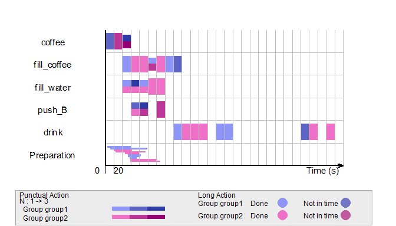

### Method : Within

All individual execution are represented and under executions of the selected group.

```r
group <- c( "group2","group1","group2","group1","group1","group2","group1","group1","group1","group2")
visi1 <- visielse( X,group=group, book=book ,informer = NULL, method = "within",grwithin = "group1")
```

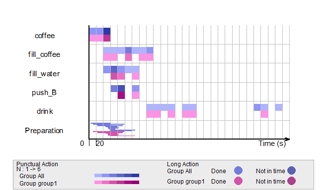